# Hw10

# Exercise 11.3

null hypothesis: 輪到該位打者，而他將如期進行打擊

Type 1 error: 你將他換下場，但他其實可以打出安打追平比分

Type 2 error: 你沒有將他換下場，但他最終沒有擊出安打

此時較好的辦法應是讓他繼續進行打擊，因其有高機率會擊出安打追平比分；即使此局單單追平無法獲勝仍有延長賽可以把握。

# Exercise 11.5

null hypothesis: 座艙傳出煙味但仍在航行

Type 1 error: 你下令立即降落，但飛機其實是安全的

Type 2 error: 飛機不是安全的，但你仍繼續往最近的機場航行

此時應立即降落以免發生危險危機乘客生命安全

# Exercise 11.11

```r
test_11 = (80-70)/(20/sqrt(100))
pvalue_11 = 1 - pnorm(test_11)
xvalue_11 = 70+qnorm(0.99)*20/sqrt(100)
reject_11 = 0.01

cat(" the value of test statistic is ", test_11 , "\n", "the rejection region is when the value of x > ", xvalue_11, "\n", "the p-value is ", pvalue_11, "\n", "Since p-value < 0.01, and there is overwhelming evidence that supports the alternative hypothesis, hence we reject the null hypothesis")
```

```
##  the value of test statistic is  5
##  the rejection region is when the value of x >  74.6527
##  the p-value is  2.866516e-07
##  Since p-value < 0.01, and there is overwhelming evidence that supports the alternative hypothesis, hence we reject the null hypothesis
```

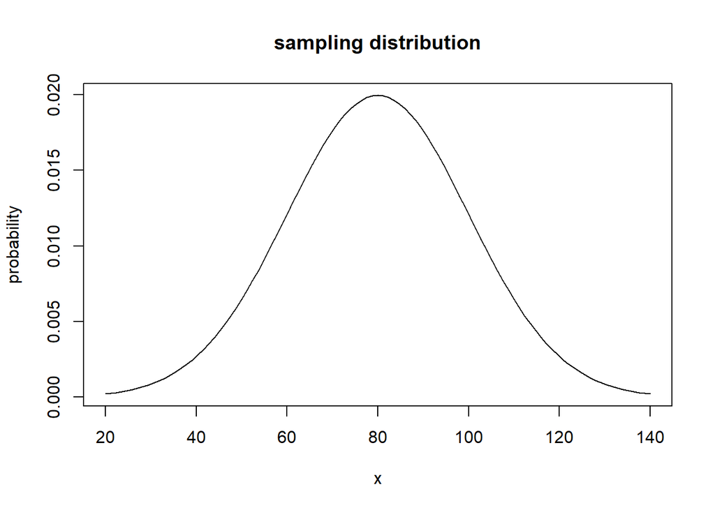

```r
curve(dnorm(x, mean = 80, sd = 20), from = 20, to = 140,ylab = "probability", main="sampling distribution")
```

# Exercise 11.15

```r
test_15 = (8.5-7.5)/(1.5/sqrt(30))
pvalue_15 = 1 - pnorm(test_15)

cat("the p-value", pvalue_15, "is less than 1%, hence there is overwhelming evidence that supports the research objective.")
```

```
## the p-value 0.0001303648 is less than 1%, hence there is overwhelming evidence that supports the research objective.
```

# Exercise 11.29

## a

因題目要驗證此假設平均數是否小於900(alternatine hypothesis)，因此這筆資料(1050)沒有足夠的證據讓我們否定掉null hypothesis，因為1050>900

## b

p-value = P(x<1050), 因1050在900的右側，因此小於1050的機率範圍涵蓋900的左側及900到1050之間的範圍，此機率的值必>0.5

# Exercise 11.35

```r
a = c(15, 15.5, 16, 16.5, 17, 17.5, 18, 18.5, 19 )
v = c()
for(i in 1:9){
  v[i] = (1 -  pnorm((a[i]-17.09)/(3.87/sqrt(100))))*2
}
for(i in 1:9)
  cat("when sample changes into", a[i], ", the p-value becomes", v[i], "\n")
```

```
## when sample changes into 15 , the p-value becomes 2
## when sample changes into 15.5 , the p-value becomes 1.99996
## when sample changes into 16 , the p-value becomes 1.995146
## when sample changes into 16.5 , the p-value becomes 1.872628
## when sample changes into 17 , the p-value becomes 1.183895
## when sample changes into 17.5 , the p-value becomes 0.2894033
## when sample changes into 18 , the p-value becomes 0.01870185
## when sample changes into 18.5 , the p-value becomes 0.0002690489
## when sample changes into 19 , the p-value becomes 7.998644e-07
```

# Exercise 11.45

$H_0$ : GMAT scores remain the same during the past five years $H_1$ : GMAT scores have increased during the past five years

```r
library("readxl")
x = read_excel(path = "D:\\Xr11-45.xlsx")
meanGMAT = mean(x$GMAT)
x1 = 560 + qnorm(0.95)*50/sqrt(20)
cat( "the rejection region is when the value of x > ", x1, ", since " , meanGMAT , "<", x1 , ", we can not conclude that the dean's claim is true at 5% significance level " )
```

```
## the rejection region is when the value of x >  578.39 , since  569 < 578.39 , we can not conclude that the dean's claim is true at 5% significance level
```

# Exercise 11.55

$H_0$ : Nike’s ball will not travel farther than Titleist $H_1$ : Nike’s ball will travel farther than Titleist

```r
y = read_excel(path = "D:\\Xr11-55.xlsx")
meanDistance = mean(y$Distance)
Distance = 230 + qnorm(0.95)*10/sqrt(100)

cat( "the rejection region is when the value of x > ", Distance, ", since " , meanDistance , "<", Distance , ", we can not conclude that the Nike's claim is true at 5% significance level " )
```

```
## the rejection region is when the value of x >  231.6449 , since  231.56 < 231.6449 , we can not conclude that the Nike's claim is true at 5% significance level
```

# Exercise 11.61

```r
x2 = 1000 + qnorm(0.99)*50/sqrt(25)
error61 = pnorm((x2 - 1050)/(50/sqrt(25)))
cat("the probability of Type II Error is",error61)
```

```
## the probability of Type II Error is 0.003751512
```